# PeMS: regional flow and CHP starts on 2026-06-16

## Sources and measurements

The case covers 24 hourly frames on 2026-06-16. Los Angeles Area contains D07/D08/D12 links; San Francisco Bay Area contains D04 links. Each region has a separate map, coverage table, flow trend and CHP start-count trend below.

The cache holds 98,688 Los Angeles active-position hourly values from `flow_2026_06.binz`, 659,808 D04 five-minute source-station counts from `d04_text_station_5min_2026_06_16.txt.gz`, and 1,023 district-day CHP summaries. Available positions are averaged within Los Angeles stations. The D04 metadata join retains 658,944 values at 2,288 stations. D04 requires all twelve five-minute counts per station-hour before summation. Links use the mean of available endpoint station values, in vehicles/hour. Shared station values make link sums unsuitable as regional counts of distinct vehicles.

CHP records retain reported source-clock timestamps and locations. Categories use the supplied source-type lookup; curated source descriptions are retained. District and geographic filters retain 1,019 starts: 700 in Los Angeles and 319 in D04. Four Los Angeles district-day records lie outside the supplied extent. Verified end times are unavailable, so an event marker represents a reported start in one hour, not its duration or a verified effect on flow.

## Data preparation

`data/source.rds` contains the selected source-level records and supplied geometry. `prepare.R` converts them to the common input without downloading data. Its executed implementation appears in Appendix A. The generated `data/input.rds` is then read by the common package.

```r
library(bdynets)
source("prepare.R")
prepared_file <- prepare_example(".")
x <- read_traffic(prepared_file)
input <- readRDS(prepared_file)
index <- match(params$time_label,sub("^.* ","",x$time_labels))
stopifnot(!is.na(index))
```

The map starts at 2026-06-16 08:00 and covers 60 minutes. The default 08:00 is a demonstration selection, not a maximum-based selection. Numeric seconds and displayed labels retain the supplied source clock; they do not establish a UTC offset.

```r
knitr::kable(data.frame(Region=x$regions,
  Roads=vapply(x$regions,function(z)sum(x$roads$region==z),integer(1)),
  Whole_day_starts=vapply(x$regions,function(z)sum(x$events$region==z),integer(1))),
  caption="Whole-day regional scope")
```

Whole-day regional scope

|  | Region | Roads | Whole_day_starts |
| --- | --- | --- | --- |
| Los Angeles Area | Los Angeles Area | 4435 | 700 |
| San Francisco Bay Area | San Francisco Bay Area | 2203 | 319 |

```r
knitr::kable(head(input$flow),caption="Actual prepared road-hour records")
```

Actual prepared road-hour records

| road_id | time | flow |
| --- | --- | --- |
| 0 | 1781568000 | 360.0 |
| 1 | 1781568000 | 1726.0 |
| 2 | 1781568000 | 1550.5 |
| 3 | 1781568000 | 1713.0 |
| 4 | 1781568000 | 930.0 |
| 5 | 1781568000 | 1384.5 |

```r
knitr::kable(head(input$events[c("id","time_label","lon","lat","category","region")]),
  caption="Actual prepared event records")
```

Actual prepared event records

| id | time_label | lon | lat | category | region |
| --- | --- | --- | --- | --- | --- |
| 23633026 | 2026-06-16 00:04:00 | -118.1121 | 34.50938 | Driving risk | Los Angeles Area |
| 23633032 | 2026-06-16 00:14:00 | -116.3546 | 33.78583 | Collision | Los Angeles Area |
| 23633029 | 2026-06-16 00:18:00 | -117.8395 | 34.06887 | Road hazard | Los Angeles Area |
| 23633034 | 2026-06-16 00:23:00 | -117.8241 | 34.12063 | Road hazard | Los Angeles Area |
| 23633038 | 2026-06-16 00:24:00 | -118.2073 | 33.80432 | Fire | Los Angeles Area |
| 23633040 | 2026-06-16 00:29:00 | -118.0042 | 34.05426 | Collision | Los Angeles Area |

| Common field | Meaning |
| --- | --- |
| road_id, geometry | Unique display link and travel-ordered longitude/latitude vertices |
| from_station, to_station | Endpoint source station identifiers |
| time, flow | Source-clock hour start and endpoint-mean hourly rate |
| id, time, lon, lat | Unique report ID, reported start and coordinates |
| category, description | Source-type classification and retained source text |
| region | Explicit geographic selection label |

Both regions use the same object, plot method and global log1p thresholds. Their central-area views do not restrict regional statistics. Red diamonds mark starts in the selected hour. Geographic overlap alone does not establish a relationship between a report and a road measurement.

## Los Angeles Area

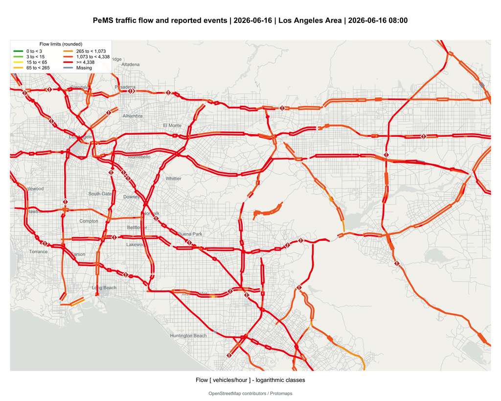

Los Angeles Area: road flow and CHP reported starts in the selected hour. Colors use the same full-day, two-region thresholds.

```r
region <- "Los Angeles Area"
plot(x,index=index,region=region)
```

```r
cols <- which(x$roads$region==region)
v <- x$values[,cols,drop=FALSE]
events <- x$events[x$events$region==region,,drop=FALSE]
knitr::kable(data.frame(
  Statistic=c("Roads","Road-hour cells","Observed cells","Missing cells","Zero cells","Whole-day starts"),
  Value=c(ncol(v),length(v),sum(!is.na(v)),sum(is.na(v)),sum(v==0,na.rm=TRUE),nrow(events))),
  caption="Whole-day coverage")
```

Whole-day coverage

| Statistic | Value |
| --- | --- |
| Roads | 4435 |
| Road-hour cells | 106440 |
| Observed cells | 105096 |
| Missing cells | 1344 |
| Zero cells | 20 |
| Whole-day starts | 700 |

```r
selected <- traffic_summary(x,index=index,region=region)
knitr::kable(selected[c("time","available","missing","zero","events")],
  caption="Selected-hour observations and starts")
```

Selected-hour observations and starts

| time | available | missing | zero | events |
| --- | --- | --- | --- | --- |
| 2026-06-16 08:00 | 4379 | 56 | 0 | 36 |

```r
knitr::kable(selected[c("minimum","median","mean","p95","maximum")],
  digits=2,caption="Selected-hour distribution [vehicles/hour]")
```

Selected-hour distribution [vehicles/hour]

| minimum | median | mean | p95 | maximum |
| --- | --- | --- | --- | --- |
| 204 | 4464.5 | 4427.63 | 7412 | 16727 |

At 2026-06-16 08:00, mean available-link flow is 4,427.63 vehicles/hour, with 36 reported starts in this hour. The whole-day total is 700 starts. These statistics have different time scopes. The 56 unavailable links in each hour produce 1,344 missing road-hour cells. The hourly export does not establish complete five-minute coverage for every underlying Los Angeles station.

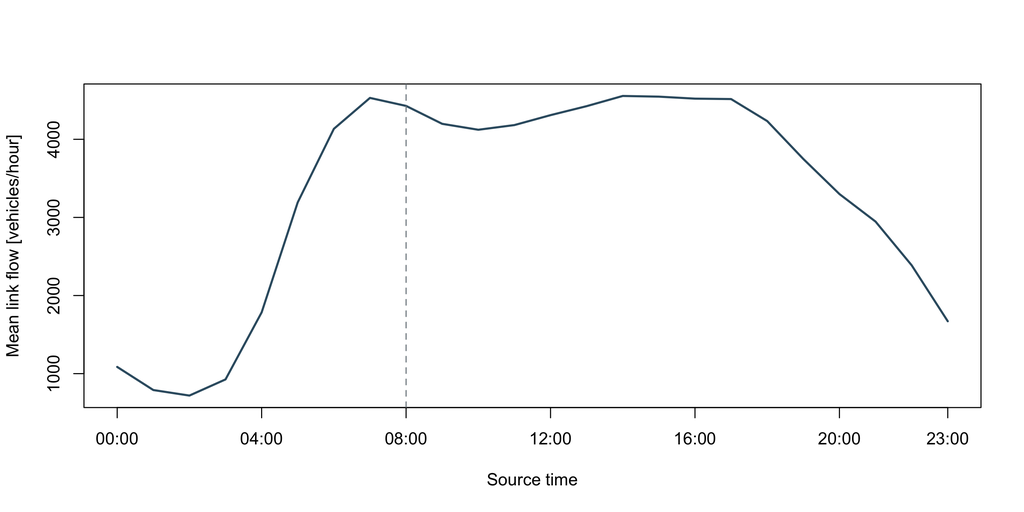

Regional mean available-link flow by hour. The dashed line marks the selected map hour.

```r
trend <- traffic_trend(x,region=region)
plot(trend$time,trend$mean,type="l",lwd=2,col="#365c70",xaxt="n",
     xlab="Source time",ylab="Mean link flow [vehicles/hour]")
at <- c(1,5,9,13,17,21,24)
axis(1,at=trend$time[at],labels=sub("^.* ","",trend$label[at]))
abline(v=x$times[index],lty=2,col="#7b858b")
```

```r
flow_peak <- which.max(trend$mean)
```

The greatest regional mean is 4,555.08 vehicles/hour at 2026-06-16 14:00. Missing link values are excluded from the mean. This curve does not measure speed or regional vehicle totals.

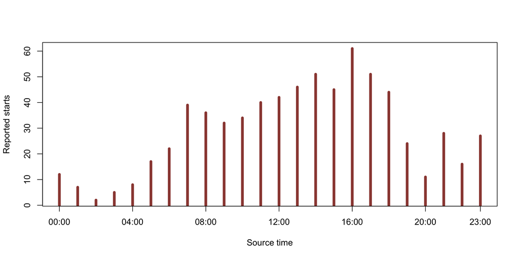

Reported event starts per source-clock hour, without inferred durations.

```r
plot(trend$time,trend$events,type="h",lwd=5,col="#9b4840",xaxt="n",
     xlab="Source time",ylab="Reported starts")
axis(1,at=trend$time[at],labels=sub("^.* ","",trend$label[at]))
```

```r
event_peak <- which.max(trend$events)
```

The largest hourly count is 61 starts at 2026-06-16 16:00. A coincident change in flow would not by itself establish an event effect.

## San Francisco Bay Area

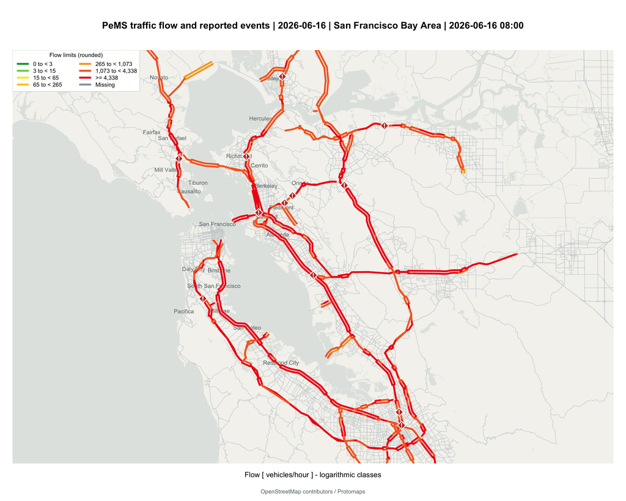

San Francisco Bay Area: road flow and CHP reported starts in the selected hour. Colors use the same full-day, two-region thresholds.

```r
region <- "San Francisco Bay Area"
plot(x,index=index,region=region)
```

```r
cols <- which(x$roads$region==region)
v <- x$values[,cols,drop=FALSE]
events <- x$events[x$events$region==region,,drop=FALSE]
knitr::kable(data.frame(
  Statistic=c("Roads","Road-hour cells","Observed cells","Missing cells","Zero cells","Whole-day starts"),
  Value=c(ncol(v),length(v),sum(!is.na(v)),sum(is.na(v)),sum(v==0,na.rm=TRUE),nrow(events))),
  caption="Whole-day coverage")
```

Whole-day coverage

| Statistic | Value |
| --- | --- |
| Roads | 2203 |
| Road-hour cells | 52872 |
| Observed cells | 52872 |
| Missing cells | 0 |
| Zero cells | 40 |
| Whole-day starts | 319 |

```r
selected <- traffic_summary(x,index=index,region=region)
knitr::kable(selected[c("time","available","missing","zero","events")],
  caption="Selected-hour observations and starts")
```

Selected-hour observations and starts

| time | available | missing | zero | events |
| --- | --- | --- | --- | --- |
| 2026-06-16 08:00 | 2203 | 0 | 2 | 18 |

```r
knitr::kable(selected[c("minimum","median","mean","p95","maximum")],
  digits=2,caption="Selected-hour distribution [vehicles/hour]")
```

Selected-hour distribution [vehicles/hour]

| minimum | median | mean | p95 | maximum |
| --- | --- | --- | --- | --- |
| 0 | 4228 | 4182.51 | 6971.75 | 9471 |

At 2026-06-16 08:00, mean available-link flow is 4,182.51 vehicles/hour, with 18 reported starts in this hour. The whole-day total is 319 starts. These statistics have different time scopes. All 52,872 D04 road-hour values are present. The source has 2,291 mainline stations; 400665, 406767 and 418817 lack matched geometry and are excluded. The 2,288 retained stations have complete five-minute timestamps. Detector imputation may still be present. Six event summaries lack detail messages and remain included.

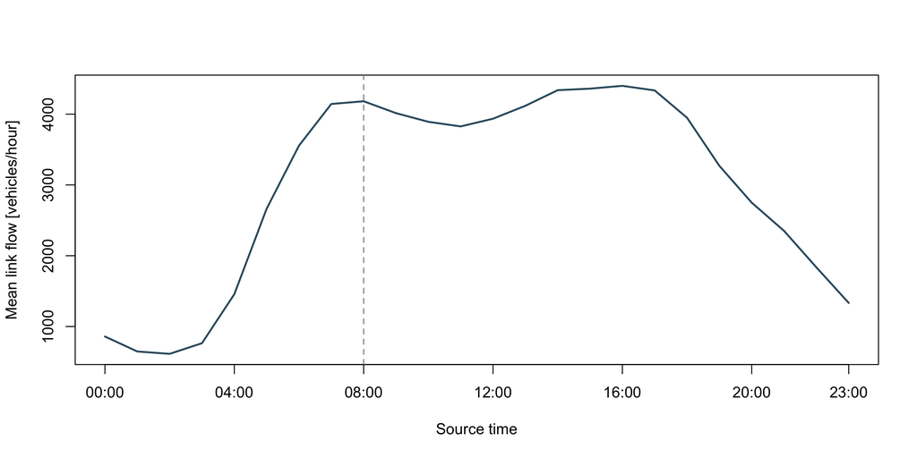

Regional mean available-link flow by hour. The dashed line marks the selected map hour.

```r
trend <- traffic_trend(x,region=region)
plot(trend$time,trend$mean,type="l",lwd=2,col="#365c70",xaxt="n",
     xlab="Source time",ylab="Mean link flow [vehicles/hour]")
at <- c(1,5,9,13,17,21,24)
axis(1,at=trend$time[at],labels=sub("^.* ","",trend$label[at]))
abline(v=x$times[index],lty=2,col="#7b858b")
```

```r
flow_peak <- which.max(trend$mean)
```

The greatest regional mean is 4,400.41 vehicles/hour at 2026-06-16 16:00. Missing link values are excluded from the mean. This curve does not measure speed or regional vehicle totals.

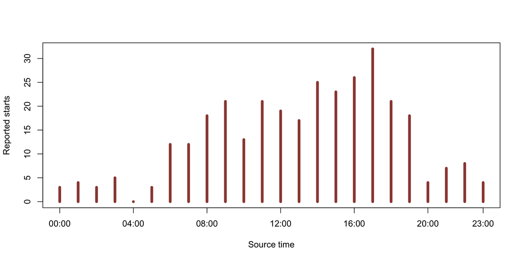

Reported event starts per source-clock hour, without inferred durations.

```r
plot(trend$time,trend$events,type="h",lwd=5,col="#9b4840",xaxt="n",
     xlab="Source time",ylab="Reported starts")
axis(1,at=trend$time[at],labels=sub("^.* ","",trend$label[at]))
```

```r
event_peak <- which.max(trend$events)
```

The largest hourly count is 32 starts at 2026-06-16 17:00. A coincident change in flow would not by itself establish an event effect.

## Figure and data export

Both regional exports call the same package interface. They contain PNG/PDF maps and trends, exact selected records, summary/trend CSV files, metadata, input/output MD5 checksums and runtime information. The selection retains the complete input’s scale; it is an inspection artifact, not a new input bundle. Existing export directories are refused. The report parameter `export` defaults to false and creates no export directory during ordinary rendering.

```r
if(params$export) {
  label <- gsub("[^[:alnum:]_-]+","-",x$time_labels[index])
  for(region in x$regions) {
    name <- gsub(" ","-",tolower(region))
    traffic_export(x,file.path(params$export_dir,paste(name,label,sep="-")),
      index=index,region=region,
      input_files=c(source="data/source.rds",prepared="data/input.rds"))
  }
}
```

## Basemap source

The figures use the supplied offline OSM-derived context. Basemap build dates identify the context snapshot, independently of the traffic date or simulation day. Generalized map features are suitable for display, not a routable road graph. Map data © [OpenStreetMap contributors](https://www.openstreetmap.org/copyright); basemap extraction uses Protomaps archives distributed as ODbL Produced Works.

| Item | Value |
| --- | --- |
| Region | Los Angeles Area |
| Archive URL | https://build.protomaps.com/20261020.pmtiles |
| Build date | 2026-10-20 |
| Retrieved UTC | 2026-10-21T06:51:16.354426+00:00 |
| Zoom | 9 |
| Recorded bounds (south, west, north, east) | 33.37494, -119.23426, 35.63265, -114.52967 |
| License | OSM-derived Protomaps basemap, ODbL Produced Work |

| Item | Value |
| --- | --- |
| Region | San Francisco Bay Area |
| Archive URL | https://build.protomaps.com/20261012.pmtiles |
| Build date | 2026-10-12 |
| Retrieved UTC | 2026-10-15T13:23:00.885383+00:00 |
| Zoom | 9 |
| Recorded bounds (south, west, north, east) | 36.59789, -123.75000, 39.36828, -120.93750 |
| License | OSM-derived Protomaps basemap, ODbL Produced Work |

The source cache preserves the original tile records and geometry checksums. The cache MD5 below identifies the actual bundled copy used for this report.

The two extracts provide separate regional context. Their bounding envelope does not imply continuous cached coverage between the regions. Both basemap snapshots postdate the traffic day and do not reconstruct its historical roads.

## Appendix A: preparation implementation

The following code is the source-to-input transformation executed from `prepare.R`. The input cache supplies all objects used by this function.

```r
prepare_example <- function(base=".", source_file="data/source.rds", output_file="data/input.rds") {
  base <- normalizePath(base, mustWork=TRUE)
  source_path <- file.path(base, source_file)
  s <- readRDS(source_path)
  stopifnot(identical(s$schema, "pems-station-events-v1"))
  roads <- s$roads; roads$road_id <- as.character(roads$road_id)
  times <- s$settings$times
  stopifnot(length(times) == 24L, !anyDuplicated(s$d04$station_id),
            identical(as.numeric(s$d04$minute), seq(0, 1435, 5)))
  v <- t(s$la$position_values)
  stopifnot(nrow(v) == length(s$la$position_station), ncol(v) == 24L)
  v[v == s$la$missing_value] <- NA_real_
  sums <- rowsum(replace(v, is.na(v), 0), s$la$position_station, reorder=FALSE)
  counts <- rowsum(1L * !is.na(v), s$la$position_station, reorder=FALSE)
  la_hour <- sums / counts
  la_hour[counts == 0] <- NA_real_
  stopifnot(nrow(s$d04$counts) == length(s$d04$station_id),
            !anyDuplicated(s$d04$matched_station_id))
  matched <- match(s$d04$matched_station_id, s$d04$station_id)
  stopifnot(!anyNA(matched))
  native <- s$d04$counts[matched, , drop=FALSE]
  stopifnot(nrow(native) == length(s$d04$matched_station_id), ncol(native) == 288L,
            all(is.finite(native)), all(native >= 0))
  starts <- seq.int(1L, 288L, by=12L)
  d04_hour <- Reduce(`+`, lapply(0:11, function(k) native[, starts+k, drop=FALSE]))
  rownames(d04_hour) <- s$d04$matched_station_id
  endpoint_means <- function(station_hour, selected_roads) {
    a <- station_hour[match(selected_roads$from_station, rownames(station_hour)), , drop=FALSE]
    b <- station_hour[match(selected_roads$to_station, rownames(station_hour)), , drop=FALSE]
    available <- (!is.na(a)) + (!is.na(b))
    result <- (replace(a, is.na(a), 0) + replace(b, is.na(b), 0)) / available
    result[available == 0] <- NA_real_
    t(result)
  }
  values <- matrix(NA_real_, nrow=24, ncol=nrow(roads))
  la <- which(roads$region == "Los Angeles Area")
  bay <- which(roads$region == "San Francisco Bay Area")
  stopifnot(length(la)+length(bay) == nrow(roads))
  values[, la] <- endpoint_means(la_hour, roads[la, ])
  values[, bay] <- endpoint_means(d04_hour, roads[bay, ])
  flow <- data.frame(road_id=rep(roads$road_id, 24),
    time=rep(times, each=nrow(roads)), flow=as.vector(t(values)))
  raw <- s$event_summaries
  stopifnot(!anyDuplicated(raw$id), all(substr(raw$reported_time, 1, 10) == "2026-06-16"))
  region <- ifelse(raw$district == "04", "San Francisco Bay Area", "Los Angeles Area")
  stopifnot(all(raw$district %in% c("04", "07", "08", "12")))
  scope <- s$scopes[match(region, s$scopes$region), ]
  lon <- as.numeric(raw$lon); lat <- as.numeric(raw$lat)
  keep <- is.finite(lon) & is.finite(lat) & lon >= scope$west & lon <= scope$east &
          lat >= scope$south & lat <= scope$north
  raw <- raw[keep, , drop=FALSE]; region <- region[keep]
  second <- as.integer(substr(raw$reported_time, 12, 13))*3600 +
            as.integer(substr(raw$reported_time, 15, 16))*60 +
            as.integer(substr(raw$reported_time, 18, 19))
  type <- tolower(trimws(gsub("[[:space:]]+", " ", raw$source_type)))
  lookup <- tolower(trimws(s$event_categories$source_type))
  category <- s$event_categories$category[match(type, lookup)]
  category[is.na(category)] <- "Other alert"
  events <- data.frame(id=raw$id, time=times[1]+second, lon=as.numeric(raw$lon),
    lat=as.numeric(raw$lat), category=category, description=raw$description,
    time_label=raw$reported_time, region=region, stringsAsFactors=FALSE)
  s$settings$provenance$preparation_check <- list(la_position_hours=length(s$la$position_values),
    d04_source_records=length(s$d04$counts), d04_retained_records=length(native),
    excluded_source_stations=length(s$d04$station_id)-length(matched), d04_samples_per_station_hour=12L,
    source_event_summaries=nrow(s$event_summaries), included_event_starts=nrow(events),
    excluded_by_geographic_scope=sum(!keep), missing_link_hours=sum(is.na(values)))
  input <- c(list(schema="trafficmap-input-v1", roads=roads, flow=flow, events=events), s$settings)
  input$provenance$source_cache <- list(file=basename(source_file),
    bytes=unname(file.info(source_path)$size), md5=unname(tools::md5sum(source_path)), schema=s$schema)
  stopifnot(!anyDuplicated(roads$road_id), all(flow$road_id %in% roads$road_id),
            !anyDuplicated(flow[c("road_id", "time")]),
            all(is.na(flow$flow) | (is.finite(flow$flow) & flow$flow >= 0)))
  bdynets::traffic_data(roads=roads, flow=flow, events=events,
    times=input$times, time_labels=input$time_labels, interval_seconds=input$interval_seconds,
    unit=if(is.null(input$unit)) "unit unspecified" else input$unit,
    basemap=input$basemap)
  output <- file.path(base, output_file)
  dir.create(dirname(output), recursive=TRUE, showWarnings=FALSE)
  saveRDS(input, output, compress="xz", version=3)
  invisible(output)
}
if(sys.nframe()==0L) {
  script <- sub("^--file=", "", grep("^--file=", commandArgs(FALSE), value=TRUE))
  if(length(script)!=1L) stop("Rscript entrypoint is required")
  if(!file.exists(script)) script <- gsub("~+~", " ", script, fixed=TRUE)
  prepare_example(dirname(normalizePath(script, mustWork=TRUE)))
  cat("Prepared data/input.rds\n")
}
```

## Appendix B: verification and runtime

```r
knitr::kable(data.frame(Check=names(input$provenance$preparation_check),
  Value=unlist(input$provenance$preparation_check)),caption="Executed preparation checks")
```

Executed preparation checks

|  | Check | Value |
| --- | --- | --- |
| la_position_hours | la_position_hours | 98688 |
| d04_source_records | d04_source_records | 659808 |
| d04_retained_records | d04_retained_records | 658944 |
| excluded_source_stations | excluded_source_stations | 3 |
| d04_samples_per_station_hour | d04_samples_per_station_hour | 12 |
| source_event_summaries | source_event_summaries | 1023 |
| included_event_starts | included_event_starts | 1019 |
| excluded_by_geographic_scope | excluded_by_geographic_scope | 4 |
| missing_link_hours | missing_link_hours | 1344 |

```r
knitr::kable(data.frame(File=c("source.rds","input.rds"),
  Bytes=unname(file.info(c("data/source.rds","data/input.rds"))$size),
  MD5=unname(tools::md5sum(c("data/source.rds","data/input.rds")))),
  caption="Actual bundled files")
```

Actual bundled files

| File | Bytes | MD5 |
| --- | --- | --- |
| source.rds | 2441888 | 57261aefeba047d1716a4579bbe889c8 |
| input.rds | 1881644 | ce3e824cc21efe505c254766d521b10a |